# The basics

Develop an R package within an hour

This tutorial will teach you how to quickly create an R package. We start with a motivating example, then build an R package, and in the next part share it with the world.

## Motivating example

**The problem**

In order to demonstrate the creation of an R-package, we will identify some odd behavior in `R`:

```r
c(0.5, 1.5, 2.5, 3.5) |> round()
```

```
[1] 0 2 2 4
```

We can see that–by default–`R` rounds the number `1.5` to integer `2` and the number `2.5` also to integer `2`. The reason for this behavior is the [IEC 60559 standard](https://en.wikipedia.org/wiki/Floating-point_arithmetic) where a 5 is expected to be rounded to the even digit.

**A solution**

If we’d like to round up to the next integer, we can easily define the following function:

```r
# load necessary package for between() function
library(dplyr)
# define function to load to the nearest integer
round_to_integer <- function(x){
  # calculate difference between the value and the nearest integer below
  diff <- x - floor(x)
  # for differences < 0.5, return the nearest integer below
  # for differences => 0.5, return the next nearest integer
  ifelse(between(diff, 0.5, 1), ceiling(x), floor(x))
}
```

This function rounds the vector `c(0.5, 1.5, 2.5, 3.5)` up to the *next* integer:

```r
c(0.5, 1.5, 2.5, 3.5) |> round_to_integer()
```

```
[1] 1 2 3 4
```

And it rounds the vector `c(0.49, 1.49, 2.49, 3.49)` down to the *previous* integer:

```r
c(0.49, 1.49, 2.49, 3.49) |> round_to_integer()
```

```
[1] 0 1 2 3
```

We will put this function in an R package to be able to (re)use the function and share it with others.

## Creating an R package

The goal of this workshop is to wrap the function `round_to_integer()` into a stand-alone R package, with package documentation and a referenceable [Digital Object Identifier](https://www.doi.org).

### Set-up the R session

We need the following packages to help us with building, testing and maintaining our package:

```r
library(devtools)   # development tools
library(usethis)    # automated package and project setup
library(roxygen2)   # package documentation
library(testthat)   # unit testing
```

### Prepare the package structure

We need a location for our R package. The simplest approach to creating the skeleton for an R package is to use RStudio. The following gif outlines this procedure:

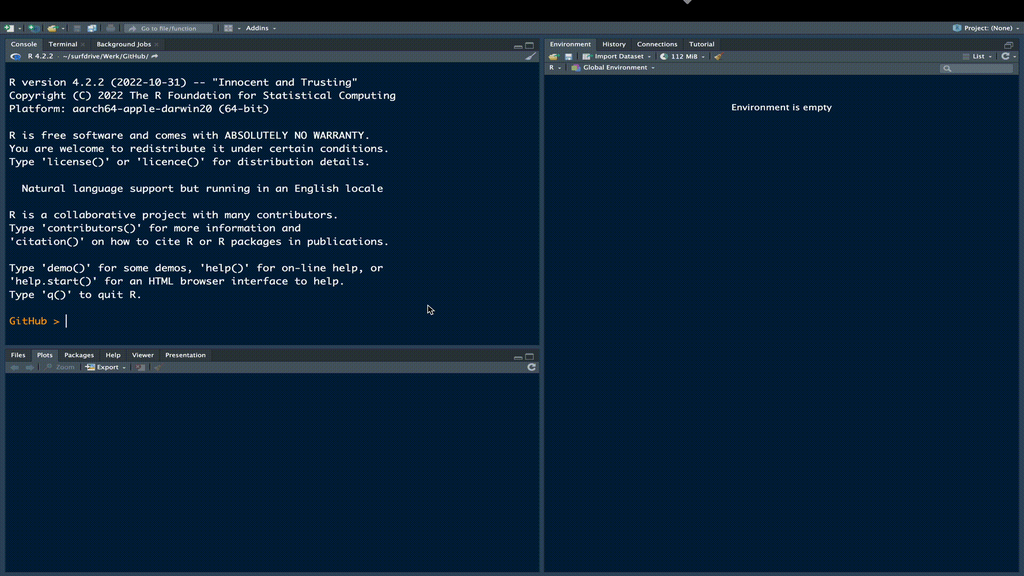

Alternatively, use the `usethis` function `create_package()`:

```r
usethis::create_package(path = "../roundR")
```

As you might notice, `usethis` is an “incredibly chatty program”[^1]. It sets up a new project, with a folder structure and some required documents. We will go over the relevant folders and documents one-by-one.

```
✔ Creating ../roundR/.
✔ Setting active project to "/path/on/your/machine/roundR".
✔ Creating R/.
✔ Writing DESCRIPTION.
Package: roundR
Title: What the Package Does (One Line, Title Case)
Version: 0.0.0.9000
Authors@R (parsed):
    * First Last <first.last@example.com> [aut, cre]
Description: What the package does (one paragraph).
License: `use_mit_license()`, `use_gpl3_license()` or friends to
    pick a license
Encoding: UTF-8
Roxygen: list(markdown = TRUE)
RoxygenNote: 7.3.3
✔ Writing NAMESPACE.
✔ Writing roundR.Rproj.
✔ Adding "^roundR\\.Rproj$" to .Rbuildignore.
✔ Adding ".Rproj.user" to .gitignore.
✔ Adding "^\\.Rproj\\.user$" to .Rbuildignore.
✔ Opening /path/on/your/machine/roundR/ in a new session.
✔ Setting active project to "<no active project>".
```

### Explore the package structure

We have now created the necessary structure for an R package. We can see this structure and the generated package files in the *File Pane* in RStudio.

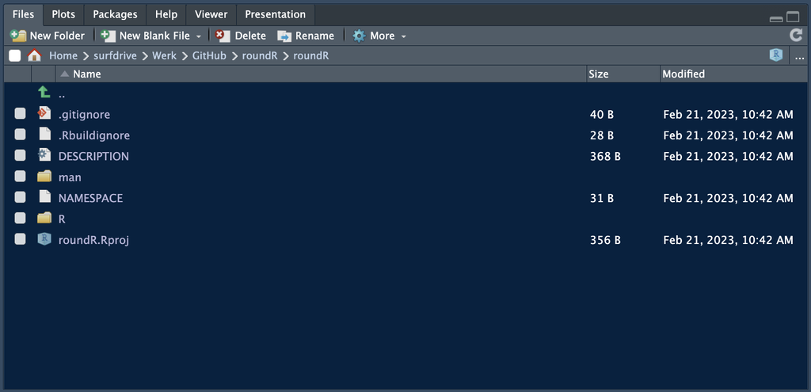

The *R* subfolder contains all the R code for your package and the *man* folder contains all the corresponding function documentation (i.e., what is shown using the `help()` function in R).

By default, for a new R package generated by RStudio the file `hello.R` is generated inside the *R* directory.

[figure not shown]

As a matter of fact, the skeleton R package is already a fully functional R package. Try installing the package in the `Build` pane.

[figure not shown]

### Edit the description

Open the file `DESCRIPTION` from the file pane. The following window opens:

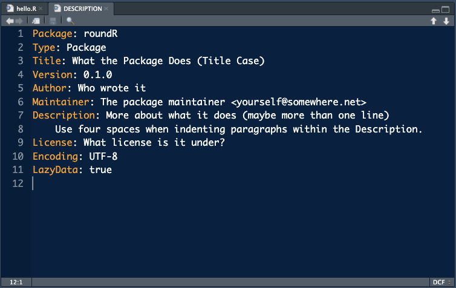

Now, replace the contents of the `DESCRIPTION` file with

```r
Package: roundR
Type: Package
Title: Round Numeric Values to the Nearest Integer
Version: 0.0.1
Authors@R: c(
    person(
      "Hanne", "Oberman",
      email = "h.i.oberman@uu.nl",
      role = c("aut", "cre")
    ),
    person(
      "Gerko", "Vink",
      email = "g.vink@uu.nl",
      role = c("aut")
    )
  )
Description: By default, R rounds numeric values to even integers, following
    the IEC 60559 standard. This package offers alternative functionality to
    round to the closest integer.
License: What license is it under?
Encoding: UTF-8
LazyData: true
```

The `DESCRIPTION` file governs the information about the licence, authors, contributors, maintainers, etc. The argument `lazyData: true` indicates that data sets should be lazily loaded. This means that data will not occupy any memory unless it is needed. This is a good argument to have as default.

We also need to set a license. Running the following code from package `usethis` will write a permissive MIT license to the description file:

```r
usethis::use_mit_license()
```

To learn more about licencing, see the [R Packages book](https://r-pkgs.org/license.html).

Don’t forget to save the updated DESCRIPTION file and change our names to your name.

### Add the functional code

Now it is time to extend the package with the functionality we promised in our updated `DESCRIPTION`. To do so, we can either manually add a new file in the *R* folder called `round_to_integer.R`, or do it programmatically:

```r
usethis::use_r("round_to_integer")
```

The `use_r()` function from the `usethis` package is very convenient, because it creates the necessary file in the correct location and opens the file in the editor pane.

We can now copy our own rounding function to the `round_to_integer.R` file:

```r
round_to_integer <- function(x){
  # calculate difference between the value and the nearest integer below
  diff <- x - floor(x)
  # for differences < 0.5, return the nearest integer below
  # for differences => 0.5, return the next nearest integer
  ifelse(between(diff, 0.5, 1), ceiling(x), floor(x))
}
```

### Set-up the package documentation

Now that we have created the file for our functional code, and added the code itself, we should make the code file recognizable by R as a package function by adding function documentation.

The most flexible approach to creating and maintaining package documentation is to use “roxygen”, a special kind of code commenting style. The `roxygen2` package is a convenient in-line documentation convention that generates a bunch of machine-readable files that are required for R packages, such as the `NAMESPACE` file and help files (one for each function in your package; collected as `.Rd` files in the *man* folder).

The *man* folder contains all documentation files. However, you can imagine if we have two separate locations for our R code and our `Rd` help files, that at some point the code and documentation might get out of sync. For example, if we update the code, but forget to reflect changes in our manual, the usability of our package may be at stake and documentation to end-users might get confusing. Most of all, it would be a lot of work for us to maintain multiple linked files in multiple locations. `roxygen2` solves this for us by extracting the documentation from our R code file. The only thing we need to do is maintain a single file: the code file in the *R* folder with some special code comments in roxygen style.

A minimal example of roxygen code comments would be as follows, matching an R function with arguments `x` and `y`:

```
#' A short description of your function
#'
#' @param x The expected input for the first function argument, x.
#' @param y Input for the second argument denoted by the letter y.
#' @returns A short description of the expected function output.
```

To start with `roxygen2` in our package, we need to instruct the package to start using `roxygen2`:

```r
usethis::use_roxygen_md()
```

The above call will add the following two lines to our `DESCRIPTION` file, indicating that the package is documented using `roxygen2`.

```
RoxygenNote: 7.3.3
Roxygen: list(markdown = TRUE)
```

### Write the function documentation

In RStudio, it is very easy to automatically insert the necessary roxygen code comments into to your function file. Place your cursor anywhere in the function code (click inside the `round_to_integer()` function definition in the `round_to_integer.R` file). Then click *Code* $\rightarrow$ *Insert Roxygen Skeleton* to automatically create the relevant roxygen documentation. The following code comments will appear:

```
#' Title
#'
#' @param x
#'
#' @returns
#' @export
#'
#' @examples
```

Filling in the roxygen skeleton–with some customization and examples–could result in the following `round_to_integer.R` code file:

```r
#' Round to the nearest integer
#'
#' The \code{\link{base::round}} function rounds the number `1.5` to
#' `2` and the number `2.5` also to `2`, because of the IEC 60559 standard.
#' This function provides an integer rounding alternative to
#' \code{\link{base::round}}.
#'
#' @param x A numeric element or vector to round to the nearest integer
#' @returns An integer element or vector
#'
#' @author Gerko Vink \email{g.vink@uu.nl} and Hanne Oberman
#' \email{h.i.oberman@uu.nl}
#'
#' #' @examples
#' # unexpected rounding
#' c(0.5, 1.5, 2.5, 3.5) |> round()
#' # rounding to nearest integer
#' c(0.5, 1.5, 2.5, 3.5) |> round_to_integer()
#'
#' @export
round_to_integer <- function(x){
  # calculate difference between the value and the nearest integer below
  diff <- x - floor(x)
  # for differences < 0.5, return the nearest integer below
  # for differences => 0.5, return the next nearest integer
  ifelse(between(diff, 0.5, 1), ceiling(x), floor(x))
}
```

You can copy the roxygen comments to your `round_to_integer.R` file. A good source to find inspiration for writing `roxygen2` documentation is [the `roxygen2` reference page](https://roxygen2.r-lib.org/articles/roxygen2.html).

### Generate the package documentation

Now that we have a working `round_to_integer.R` file with documentation code included, we can build the documentation files. A good wrapper function to render all documentation in your package is the following code evaluation:

```r
devtools::document()
```

The `document()` function from the `devtools` package will build all documentation for all files that use `roxygen2` and it will build the `NAMESPACE` of your package accordingly.

**Tip**

If you encounter the following message:

```
Skipping NAMESPACE
✖ It already exists and was not generated by roxygen2.
```

just remove the `NAMESPACE` file and re-run the `document()` function.

By now, your function should have a corresponding help file in the *man* folder, `round_to_integer.Rd`. We will remove the `R/hello.R` and `man/hello.Rd` files as they are not supposed to be part of our package.

Delete the file `hello.R` from the *R* folder manually or with:

```r
file.remove("./R/hello.R")
```

Re-render the package documentation to remove the function help file too:

```r
devtools::document()
```

## Evaluating the R package

To find out whether we’ve created a functioning R package, we can use the built-in checking tools in RStudio or the `devtools` function `check()`. The `check()` function executes an evaluation suite similar to the ones for CRAN. Whichever method you choose, they all result in an `R CMD check`, which is [“the official method for checking that an R package is valid”](https://r-pkgs.org/workflow101.html#sec-workflow101-r-cmd-check).

### Run package check

Let’s check the functionality of our package by clicking *Check* in the *Build* tab, or running:

```r
devtools::check()
```

We can see that our current package yields 1 error, 1 warning and 1 note:

```
1 error ✖ | 1 warning ✖ | 1 note ✖
```

### Investigate the error

The error message is as follows:

[output not shown]

The error arises from the examples in our documentation. But the issue itself lies within the `round_to_integer()` function code. Inside the function, we use the `between()` function from the `dplyr` package. But we did not explicitly load that package before running the example.

The examples are self-contained, meaning that any dependent packages need to be explicitly loaded via `library()` for the code to run, just like any other `R` instance. Simply adding `library(dplyr)` to the example code will solve the error.

Navigate to the `round_to_integer.R` file and add `library(dplyr)` to the examples. The examples now contain:

```r
#' @examples
#' library(dplyr)
#' # unexpected rounding
#' c(0.5, 1.5, 2.5, 3.5) |> round()
#' # rounding to nearest integer
#' c(0.5, 1.5, 2.5, 3.5) |> round_to_integer()
```

### Investigate the warning

The warning message is as follows:

```
❯ checking Rd cross-references ... WARNING
  Missing link(s) in Rd file 'round_to_integer.Rd':
    ‘base::round’

  See section 'Cross-references' in the 'Writing R Extensions' manual.

  Found the following Rd file(s) with Rd \link{} targets missing package
  anchors:
    round_to_integer.Rd: base::round
  Please provide package anchors for all Rd \link{} targets not in the
  package itself and the base packages.
```

The error stems from the cross-reference we attempted in our documentation. The proper way to refer to function `round()` from package `base` is not with `\link{base::round}`, but with `[base::round()]` following the structure [`[otherpkg::otherfunction()]`](https://r-pkgs.org/man.html#sec-man-key-md-features). We could have opted for not referencing or linking the `round()` function at all, but this would not align with open and inclusive development conventions.

Correct the faulty cross-references in the documentation:

```r
#' The [base::round()] function rounds the number `1.5` to `2` and the number
#' `2.5` also to `2`, because of the IEC 60559 standard. This function provides
#' an integer rounding alternative to [base::round()].
```

### Investigate the note

The note message is as follows:

```
❯ checking R code for possible problems ... NOTE
  round_to_integer: no visible global function definition for ‘between’
  Undefined global functions or variables:
    between
```

We use function `between()` from package `dplyr`, but we neglected to make explicit that the function `between()` is required for our function `round_to_integer()` to work. In other words, `R` needs to know that our package `roundR` would depend on package `dplyr` for its functionality to work.

We can fix this in two steps: 1) Tell R explicitly that we are using the `between()` function from the `dplyr` package in the definition of our function by adding `dplyr::` to the function body:

```r
round_to_integer <- function(x){
  # calculate difference between the value and the nearest integer below
  diff <- x - floor(x)
  # for differences < 0.5, return the nearest integer below
  # for differences => 0.5, return the next nearest integer
  ifelse(dplyr::between(diff, 0.5, 1), ceiling(x), floor(x))
}
```

and 2) Add `dplyr` as a dependency to our package by importing the required `between()` function:

```r
usethis::use_import_from("dplyr", "between")
```

**Tip**

When asked:

```
! `use_import_from()` requires package-level documentation.
  Would you like to add it now?

1: No way
2: Not now
3: For sure

Selection:
Enter an item from the menu, or 0 to exit
```

choose the fun option that would add it (i.e. `For Sure`, `Yes`, `Absolutely`, etc). These options change every time you re-run the function code, so read it carefully!

In the folder *R*, there should now be a new file `roundR-package.R` with some roxygen code, which means we have to re-run `devtools::document()` to update our documentation.

### Re-render documentation

Update the package documentation with:

```r
devtools::document()
```

Evaluate what happened. What has changed in our `DESCRIPTION` and `NAMESPACE` files? If you want to learn more about R package dependencies, see the [Dependencies](https://r-pkgs.org/dependencies-in-practice.html#sec-dependencies-in-imports-r-code) and [Imports](https://r-pkgs.org/description.html#sec-description-imports-suggests) section in the R Packages book.

### Re-run checks

Try re-running the `check()` to see if you hit three green check marks (no more errors, warnings and notes):

```r
devtools::check()
```

If all is well, you’ll see:

[output not shown]

This means that, in principle, you could go ahead and submit this package to CRAN. But let’s first try and use our new package locally.

### Try the package

During R package development, you will probably often try and see whether your code runs as expected–specifically whether your functions work as you’d hoped. Your new favorite function might be `devtools::load_all()`.

Load the current development version of the package:

```r
devtools::load_all()
```

Run some code to try our function from the loaded package, for example:

```r
round_to_integer(2.5)
```

Instead of running R code manually to verify whether our function performs as expected, we can automate this with tests.

### Add tests

The next step for a mature package is to include tests. Every function should have functional tests. The `testthat` package is geared to that. Make sure that you have the `round_to_integer.R` file open in the *Source* pane and run:

```r
usethis::use_test()
```

The proper structure for test files has now been created:

```
✔ Adding 'testthat' to Suggests field in DESCRIPTION
✔ Setting Config/testthat/edition field in DESCRIPTION to '3'
✔ Creating 'tests/testthat/'
✔ Writing 'tests/testthat.R'
✔ Writing 'tests/testthat/test-round_to_integer.R'
• Modify 'tests/testthat/test-round_to_integer.R'
```

You are asked to modify the `tests/testthat/test-round_to_integer.R` file. Replace the example test with:

```r
test_that("round_to_integer works", {
  A <- c(0.5, 1.5, 2.5, 3.5) |> round_to_integer()
  B <- c(0.49, 1.49, 2.49, 3.49) |> round_to_integer()
  expect_equal(A, c(1, 2, 3, 4))
  expect_equal(B, c(0, 1, 2, 3))
})

test_that("round_to_integer yields different results than round", {
  vec1 <- c(0.5, 1.5, 2.5, 3.5)
  vec2 <- c(
    0.499999999999999999995,
    1.499999999999999999995,
    2.499999999999999999995,
    3.499999999999999999995
  )
  A <- vec1 |> round_to_integer()
  B <- vec1 |> round()
  C <- vec2 |> round_to_integer()
  D <- vec2 |> round()
  expect_false(identical(A, B))
  expect_false(identical(C, D))
})
```

Click the `Test` button in the *Build* pane, or run:

```r
devtools::test()
```

All test should pass, meaning that your `round_to_integer()` function yields correct results (test 1) that differ fundamentally from the results obtained with `round()` (test 2).

If test would fail, you’d be notified. For example

```r
test_that("round_to_integer works", {
  A <- c(0.5, 1.5, 2.5, 3.5) |> round_to_integer()
  expect_equal(A, c(4, 3, 2, 1))
  })
```

```
── Failure: round_to_integer works ─────────────────────────────────────────────
`A` not equal to c(4, 3, 2, 1).
4/4 mismatches (average diff: 2)
[1] 1 - 4 == -3
[2] 2 - 3 == -1
[3] 3 - 2 ==  1
[4] 4 - 1 ==  3
```

```
Error:
! Test failed
```

Fortunately, our test all passed. Now re-run the `R CMD check`. If all is well you’ll receive confirmation of a successful check.

### Increase the version

Now that we have a working package with successful checks, we might think about updating the version of the package. After all, a lot has changed since the package got defined at the start of our development journey.

The easiest means to increasing the version to `0.1.0` (indicating a minor update) is to use

```r
usethis::use_version(which = "minor")
```

**Tip**

You will be presented with something like:

```
✔ Adding "0.1.0" to Version.
ℹ There is 1 uncommitted file:
• DESCRIPTION
! Is it ok to commit it?

1: Definitely
2: Absolutely not
3: Negative

Selection:
```

The question `Is it ok to commit it?` is related to `git`. Please select the affirmative option (such as `Definitely`) to commit the version increase. For reasons of brevity and simplicity, we will leave a thorough discussion of incremental `git` commits for now and demonstrate to use of `git` and GitHub at the end of this walk through.

### Install your new package

Install the package by clicking *Install* in the *Build* tab. In the console, the following should occur:

```
Restarting R session...
> library(roundR)
```

Your package is now ready to use locally, but not yet ready to share with the world… That’s what the next part is all about!

—  
Copyright Hanne Oberman, 2025 - [CC BY-NC-SA 4.0](https://creativecommons.org/licenses/by-nc-sa/4.0/)  
Materials developed by [Amices](https://amices.org) team - Methodology & Statistics - Utrecht University

## Footnotes

[^1]: Quote by `usethis` developer Jenny Bryan